# Data Visualization

## Overview

- Making plots with base R
- Making plots with `ggplot2` package
  - Main concept: “linking” data with the plot elements
  - First plot
  - Specifying plot layers: line, point, boxplot, …
  - Customizing plot look: title, axis labels, background colors, …
  - Combining multiple plots
  - Saving a plot to file

## Making plots with base R

- Pros: the fastest way to make a plot
- Cons: limits for plot customization

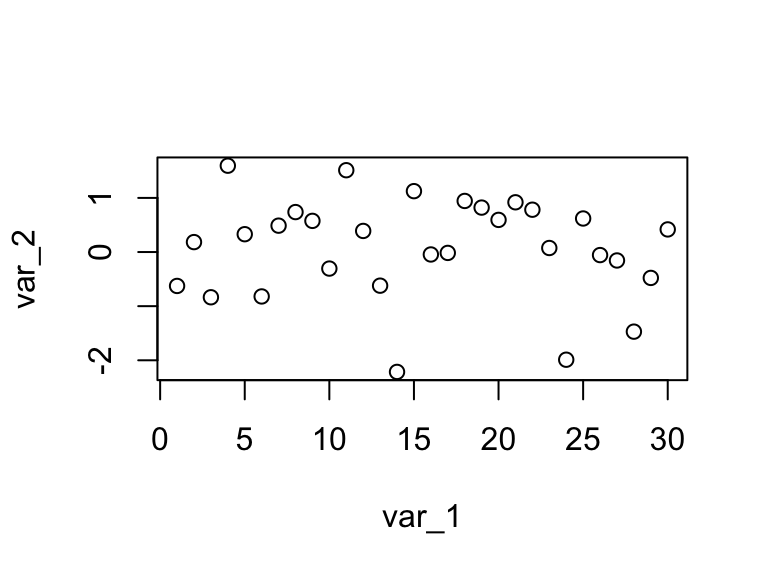

```r
var_1 <- seq(from = 1, to = 30)
var_2 <- rnorm(30)

plot(x = var_1, y = var_2)
```

## Making plots with base R

Often, you want to plot the data straight from a data frame

```r
# creating a data frame from the vectors we had
my_data = data.frame(var_1, var_2)
my_data
```

```
   var_1       var_2
1      1 -0.62645381
2      2  0.18364332
3      3 -0.83562861
4      4  1.59528080
5      5  0.32950777
6      6 -0.82046838
7      7  0.48742905
8      8  0.73832471
9      9  0.57578135
10    10 -0.30538839
11    11  1.51178117
12    12  0.38984324
13    13 -0.62124058
14    14 -2.21469989
15    15  1.12493092
16    16 -0.04493361
17    17 -0.01619026
18    18  0.94383621
19    19  0.82122120
20    20  0.59390132
21    21  0.91897737
22    22  0.78213630
23    23  0.07456498
24    24 -1.98935170
25    25  0.61982575
26    26 -0.05612874
27    27 -0.15579551
28    28 -1.47075238
29    29 -0.47815006
30    30  0.41794156
```

## Making plots with base R

Often, you want to plot the data straight from a data frame

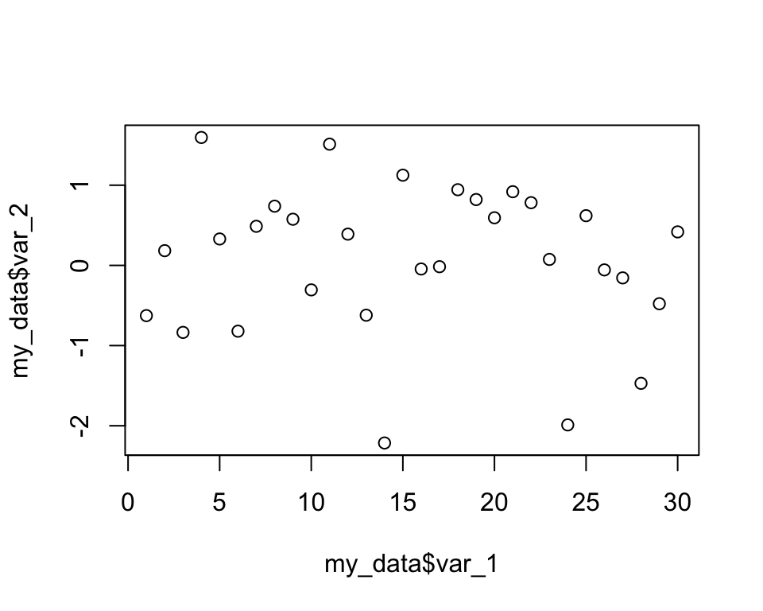

```r
# use $ to access column from a data set
plot(x = my_data$var_1, y = my_data$var_2)
```

## Making plots with base R

`plot()` is one of the functions from base R to produce a graphic.

We also have `hist()`, `boxplot()` and many others. They may vary in usage, e.g. in number of arguments we typically need to supply

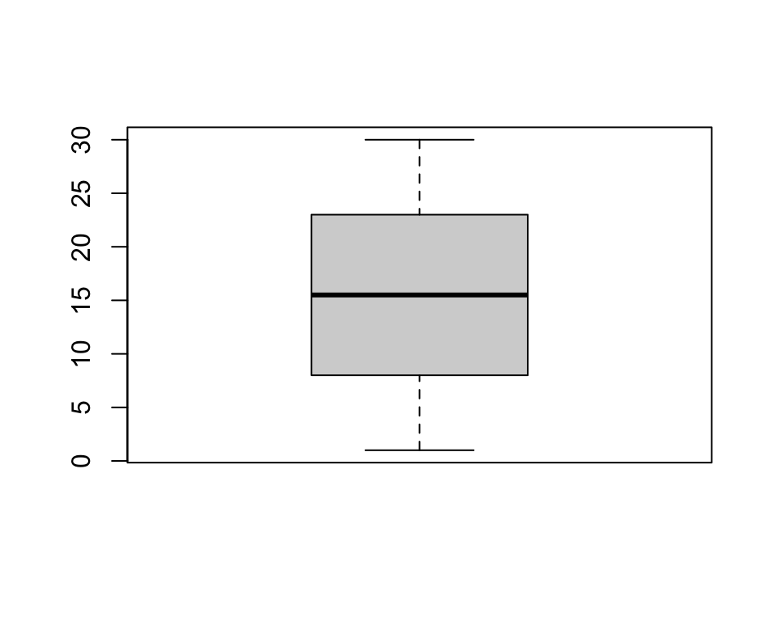

```r
# use $ to access column from a data set
boxplot(x = my_data$var_1)
```

## ggplot2

- A package for producing graphics - gg = Grammar of graphics
- Created by Hadley Wickham in 2005
- Belongs to “Tidyverse” family of packages
- *“Make a ggplot”* = Make a plot with the use of ggplot2 package
- based on the idea of **layering** plot objects on top of one another

## ggplot2

- Pros: extremely powerful/flexible – allows combining multiple plot elements together, allows high customization of a look, many resources online
- Cons: ggplot2-specific “grammar of graphic” of constructing a plot
- ggplot2 gallery

## Tidy data

To make graphics using `ggplot2`, our data needs to be in a **tidy** format

**Tidy data**:

1. Each variable forms a column.
2. Each observation forms a row.

Messy data:

- Column headers are values, not variable names.
- Multiple variables are stored in one column.
- Variables are stored in both rows and columns.

## Tidy data: example

Each variable forms a column. Each observation forms a row.

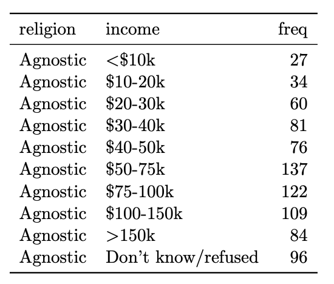

## Messy data: example

Column headers are values, not variable names

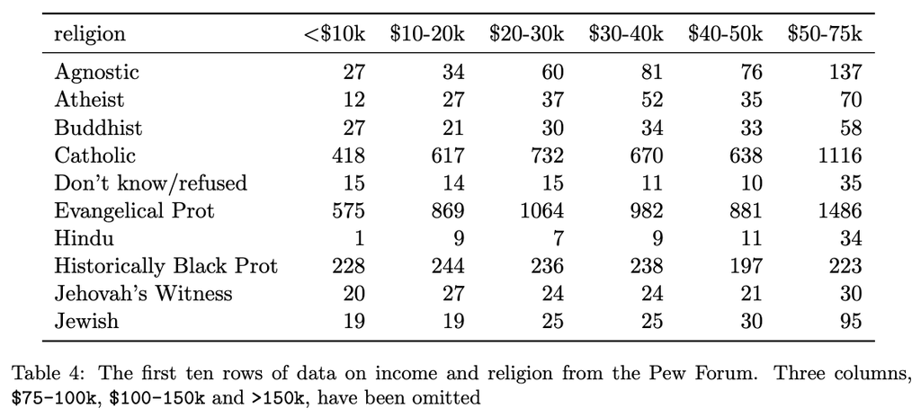

Read more about tidy data and see other examples: [Tidy Data](https://vita.had.co.nz/papers/tidy-data.pdf) tutorial by Hadley Wickham

It’s also helpful to have data in long format!!!

## First plot with `ggplot2` package

```r
head(my_data, 3)   # to recall how "my_data" data frame looks like
```

```
  var_1      var_2
1     1 -0.6264538
2     2  0.1836433
3     3 -0.8356286
```

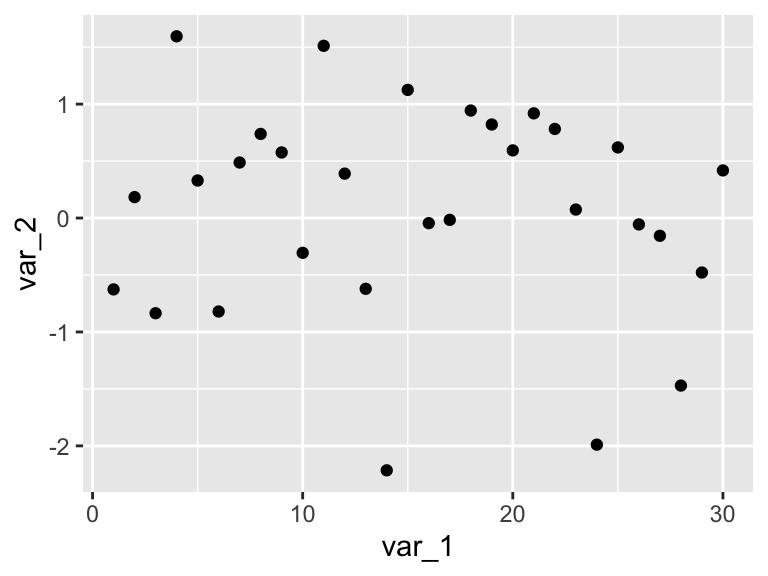

```r
library(ggplot2)

ggplot(my_data, aes(x = var_1, y = var_2)) +
  geom_point()
```

## First plot with `ggplot2` package: unpacking

```r
ggplot(my_data, mapping = aes(x = var_1, y = var_2)) +
  geom_point()
```

In the code first line, we use `ggplot()` function. It takes two arguments:

- **Data frame** (here: `my_data`)
- **Aesthetic mapping** (here: `mapping = aes(x = var_1, y = var_2)`) that describes how variables in our data are mapped to elements of the plot

  Here, can read: *take variable named `var_1` from a data frame `my_data` and use it for `x` axis; take variable named `var_2` from a data frame `my_data` and use it for `y` axis*

## First plot with `ggplot2` package: unpacking

```r
ggplot(my_data, mapping = aes(x = var_1, y = var_2)) +
  geom_point()
```

In the code second line, we have definition of a **layer** of a plot. There is only one layer here, `+ geom_point()`

- Here, can read: *add points to the plot (use data as provided by the aesthetic mapping)*

## Specifying plot layers

There are many to choose from, to list just a few:

- `geom_point()` – points (we have seen)
- `geom_line()` – lines to connect observations
- `geom_boxplot()`
- `geom_histogram()`
- `geom_bar()`
- `geom_col()`
- `geom_errorbar()`
- `geom_density()`
- `geom_tile()` – blocks filled with color

## Specifying plot layers: examples

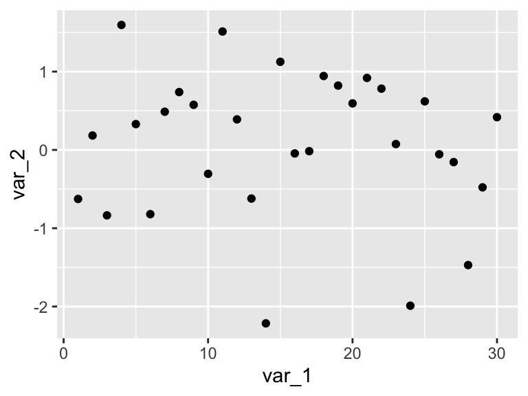

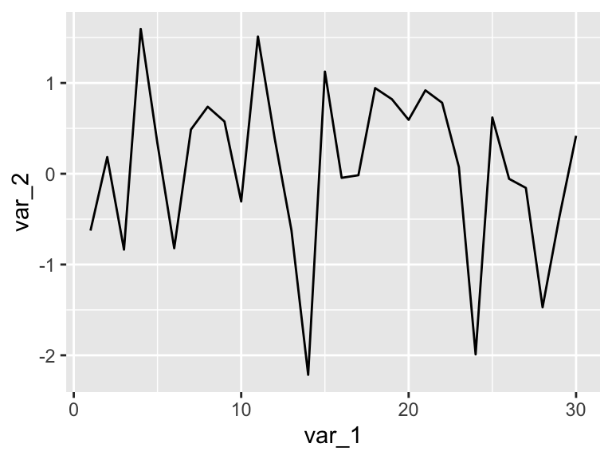

```r
plt1 <-
  ggplot(my_data, aes(x = var_1, y = var_2)) +
  geom_point()

plt2 <-
  ggplot(my_data, aes(x = var_1, y = var_2)) +
  geom_line()

plt1; plt2 # to have 2 plots printed next to each other on a slide
```

## Specifying plot layers: examples

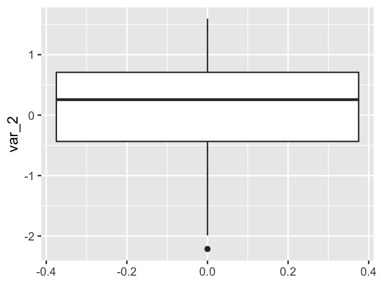

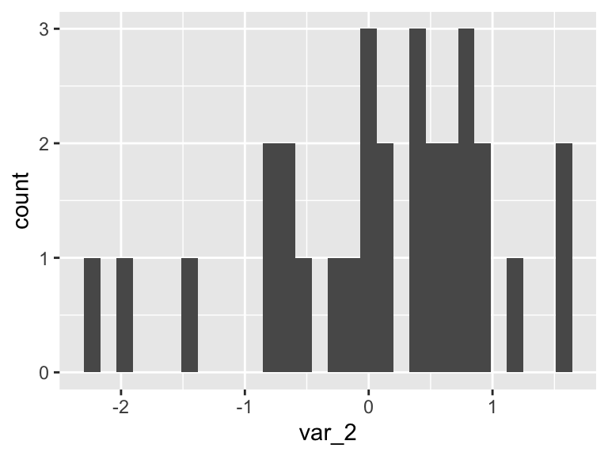

```r
plt3 <-
  ggplot(my_data, aes(y = var_2)) +
  geom_boxplot()

plt4 <-
  ggplot(my_data, aes(x = var_2)) +
  geom_histogram()

plt3; plt4 # to have 2 plots printed next to each other on a slide
```

## Specifying plot layers: combining multiple layers

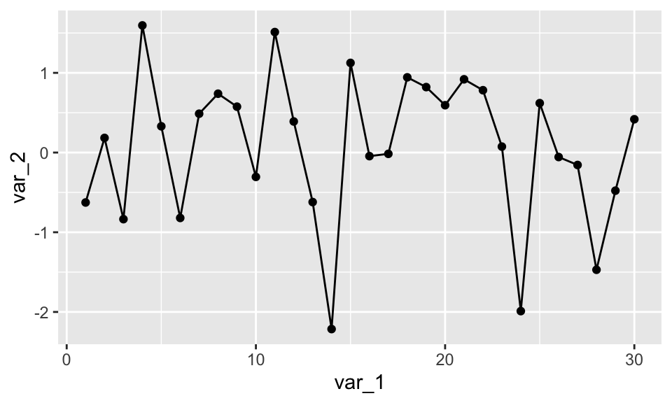

```r
ggplot(my_data, aes(x = var_1, y = var_2)) +
  geom_point() +
  geom_line()
```

## Customize the look of the plot

You can change look of each layer separately.

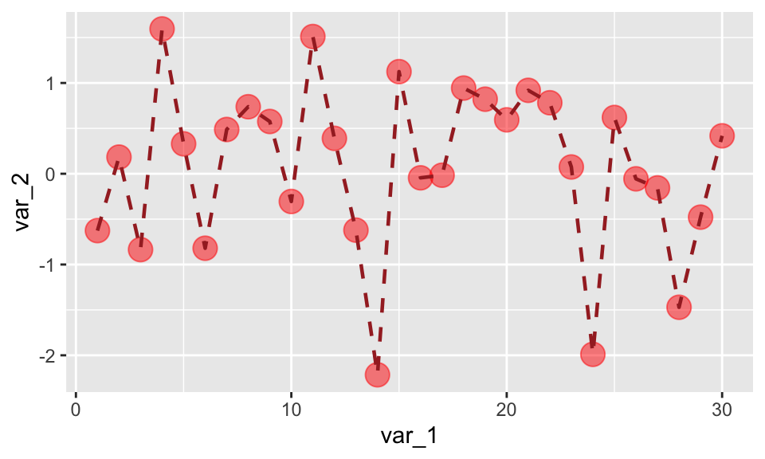

```r
ggplot(my_data, aes(x = var_1, y = var_2)) +
  geom_point(size = 5, color = "red", alpha = 0.5) +
  geom_line(size = 0.8, color = "brown", linetype = 2)
```

## Customize the look of the plot

You can change look of each layer separately. You can change the look of whole plot-specific elements, too.

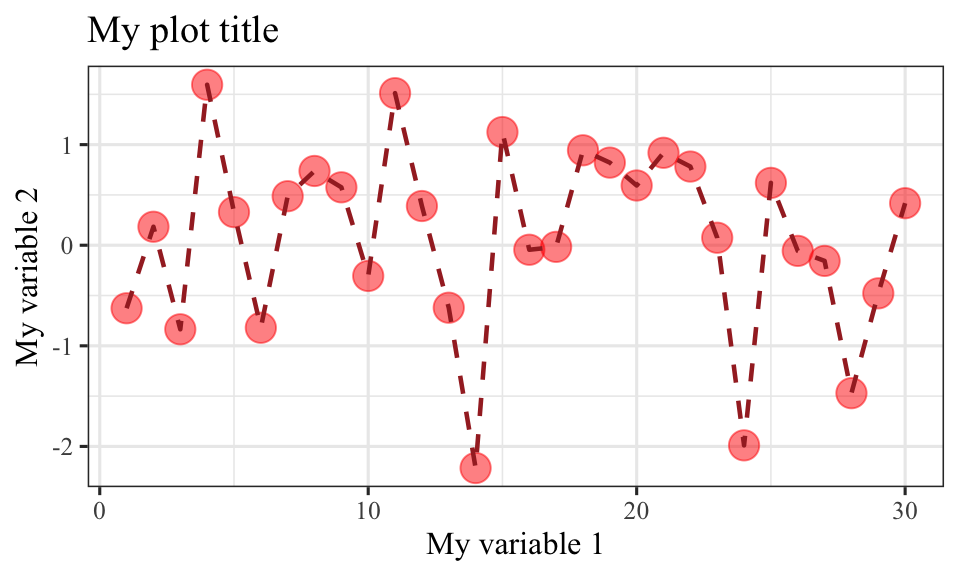

```r
ggplot(my_data, aes(x = var_1, y = var_2)) +
  geom_point(size = 5, color = "red", alpha = 0.5) +
  geom_line(size = 0.8, color = "brown", linetype = 2) +
  labs(x = "My variable 1", y = "My variable 2",
       title = "My plot title") +
  theme_bw(base_size = 12, base_family = "Times New Roman")
```

## Lab 1

Lab document: http://jhudatascience.org//intro_to_r/Data_Visualization/lab/Data_Visualization_Lab.Rmd

## Group and/or color by variable’s values

We generate some data frame for the purpose of demonstration

- 20 different items (e.g. products in a store)
- of 2 different categories (e.g. pasta, rice)
- 100 price values collected over time for each item

```r
# create 4 vectors: 2x character class and 2x numeric class
item_categ <- as.vector(sapply(1:20, function(i) rep(sample(c("pasta", "rice"), 1), 100)))
item_ID  <- rep(seq(from = 1, to = 20), each = 100)
item_ID <- paste0("ID_", item_ID)
observation_time  <- rep(seq(from = 1, to = 100), times = 20)
item_price <- as.vector(replicate(20, cumsum(rnorm(100))))
item_price <- item_price + abs(min(item_price)) + 1

# use 4 vectors to create data frame with 4 columns
df  <- data.frame(item_ID, item_categ, observation_time, item_price)
```

## Group and/or color by variable’s values

```r
head(df, 3)
```

```
  item_ID item_categ observation_time item_price
1    ID_1      pasta                1   22.53215
2    ID_1      pasta                2   22.27878
3    ID_1      pasta                3   22.97575
```

```r
tail(df, 3)
```

```
     item_ID item_categ observation_time item_price
1998   ID_20       rice               98   16.71701
1999   ID_20       rice               99   16.25430
2000   ID_20       rice              100   17.29740
```

```r
str(df)
```

```
'data.frame':   2000 obs. of  4 variables:
 $ item_ID         : chr  "ID_1" "ID_1" "ID_1" "ID_1" ...
 $ item_categ      : chr  "pasta" "pasta" "pasta" "pasta" ...
 $ observation_time: int  1 2 3 4 5 6 7 8 9 10 ...
 $ item_price      : num  22.5 22.3 23 23.5 22.8 ...
```

## Group and/or color by variable’s values

You can use `group` element in a mapping to indicate that each `item_ID` will have a separate price line (more generally: a separate layer element)

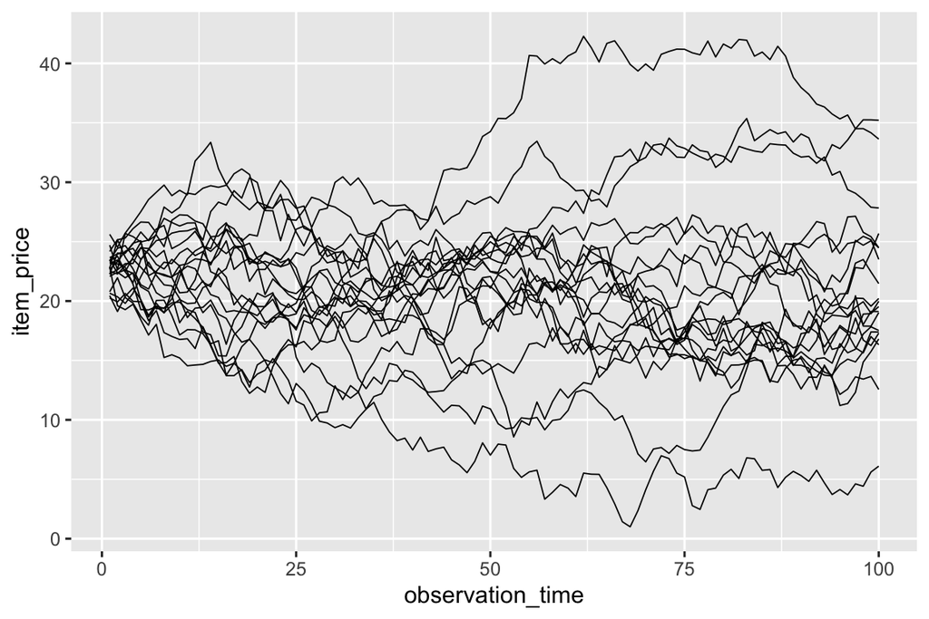

```r
ggplot(df, aes(x = observation_time, y = item_price, group = item_ID)) +
  geom_line(size = 0.3)
```

## Group and/or color by variable’s values

You can use `color` element in a mapping to indicate that each `item_categ` will have different color used.

Colors palette is selected by default (and can be modified). Legend position, legend title etc. have a default look (and can be modified).

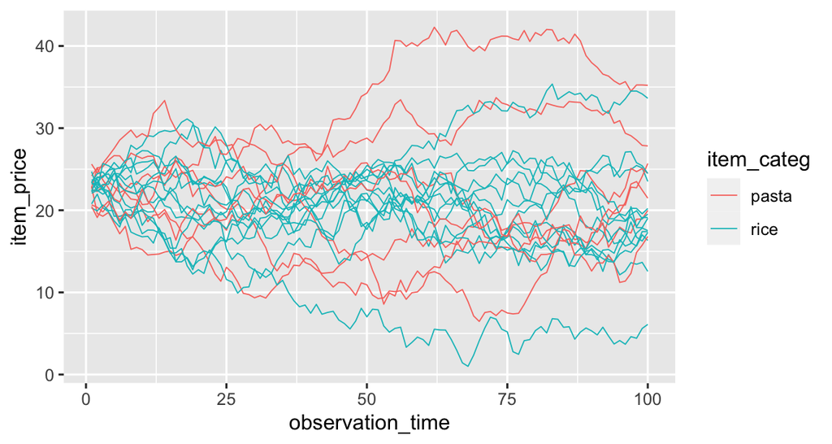

```r
ggplot(df, aes(x = observation_time, y = item_price, group = item_ID,
               color = item_categ)) +
  geom_line(size = 0.3)
```

## Group and/or color by variable’s values

Here, we use boxplot instead of lines.

Note how aesthetic mappings are defined now: `aes(x = item_ID, y = item_price)`.

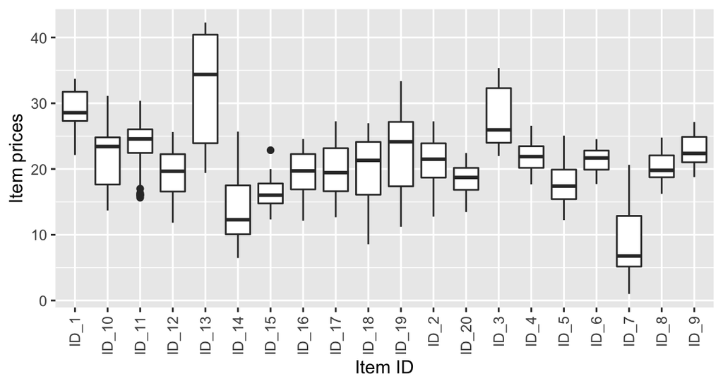

```r
ggplot(df, aes(x = item_ID, y = item_price)) +
  geom_boxplot() +
  labs(x = "Item ID", y = "Item prices") +
  theme(axis.text.x = element_text(angle = 90, vjust = 0.5, hjust = 1))
```

## Group and/or color by variable’s values

We use `color` element in mappings to indicate that each `item_categ` will have different **color of boxplot box** used.

We also use `color = "Item\ncategory"` to change name of legend.

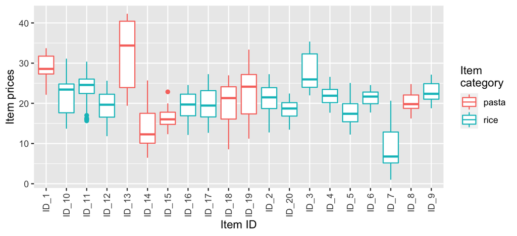

```r
ggplot(df, aes(x = item_ID, y = item_price, color = item_categ)) +
  geom_boxplot() +
  labs(x = "Item ID", y = "Item prices", color = "Item\ncategory") +
  theme(axis.text.x = element_text(angle = 90, vjust = 0.5, hjust = 1))
```

## Group and/or color by variable’s values

We use `fill` element in mappings to indicate that each `item_categ` will have different **color of boxplot filling** used.

We also use `fill = "Item\ncategory"` to change name of legend.

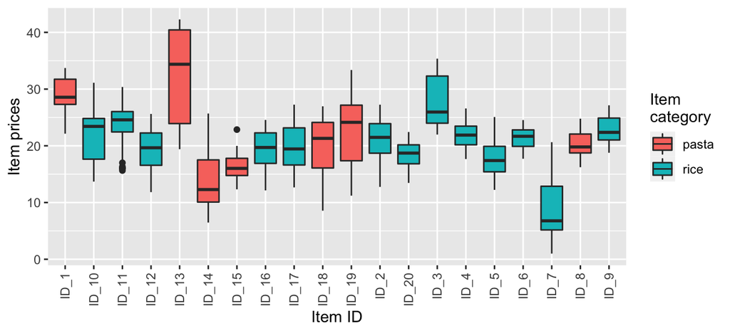

```r
ggplot(df, aes(x = item_ID, y = item_price, fill = item_categ)) +
  geom_boxplot() +
  labs(x = "Item ID", y = "Item prices", fill = "Item\ncategory") +
  theme(axis.text.x = element_text(angle = 90, vjust = 0.5, hjust = 1))
```

## Group and/or color by variable’s values

Let’s make some tweaks to item ID (`item_ID`) ordering by creating a factor version with a certain order of factor levels

```r
item_ID_levels <-
  df %>%
  group_by(item_ID) %>%
  summarise(item_price_median = median(item_price)) %>%
  arrange(item_price_median) %>%
  pull(item_ID)

df <-
  df %>%
  mutate(item_ID_factor = factor(item_ID, levels = item_ID_levels))
```

## Group and/or color by variable’s values

Same as 2 slides ago, but we replaced `item_ID` with `item_ID_factor` in mappings definition (`aes()`).

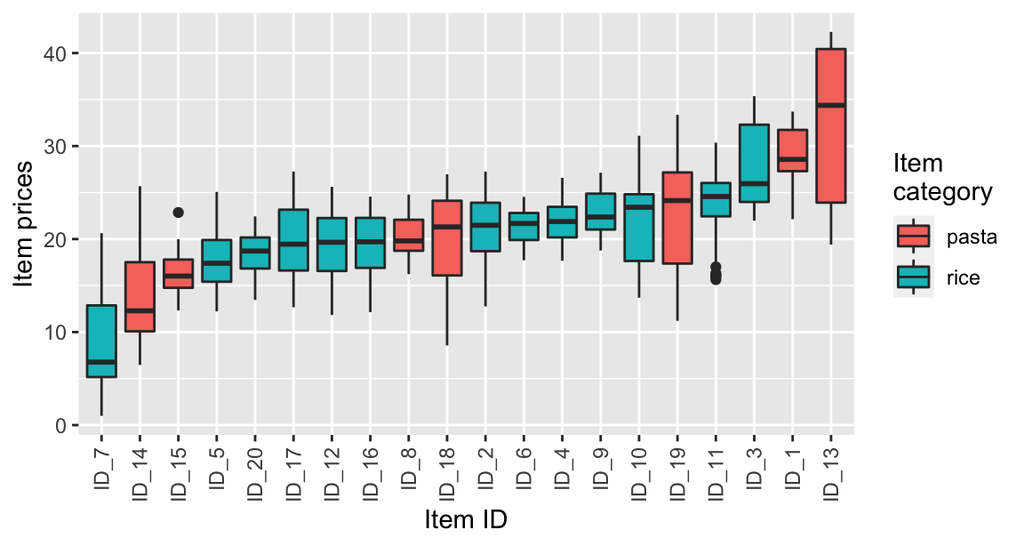

```r
ggplot(df, aes(x = item_ID_factor, y = item_price, fill = item_categ)) +
  geom_boxplot() +
  labs(x = "Item ID", y = "Item prices", fill = "Item\ncategory") +
  theme(axis.text.x = element_text(angle = 90, vjust = 0.5, hjust = 1))
```

## Split plot into panels by variable’s values

We define data subset to keep only 4 (out of 20) item IDs. We use `facet_grid(. ~ item_ID)` to split the plot into panels where each product ID has a separate panel

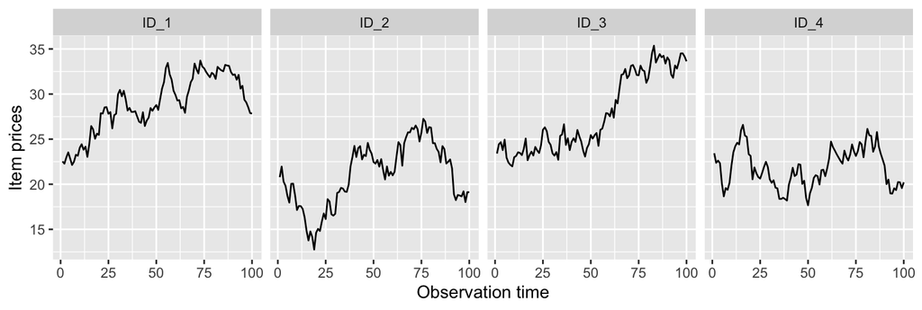

```r
df_subset <- df %>%
  filter(item_ID %in% c("ID_1", "ID_2", "ID_3", "ID_4"))

ggplot(df_subset, aes(x = observation_time, y = item_price)) +
  geom_line() +
  labs(x = "Observation time", y = "Item prices") +
  facet_grid(. ~ item_ID)
```

## Split plot into panels by variable’s values

We define data subset to keep only 4 (out of 20) item IDs. We use `facet_grid(item_ID ~ .)` to split the plot into panels where each product ID has a separate panel

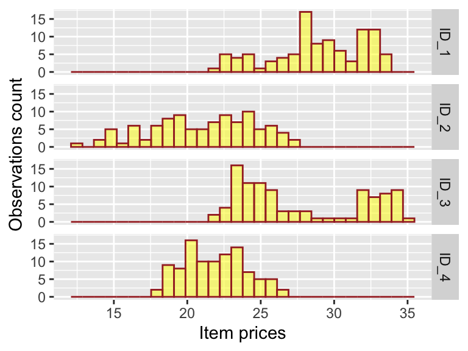

```r
ggplot(df_subset, aes(x = item_price)) +
  geom_histogram(fill = "yellow", color = "brown", alpha = 0.5) +
  labs(x = "Item prices", y = "Observations count") +
  facet_grid(item_ID ~ .)
```

## Saving a ggplot to file

A few options:

- RStudio > Plots > Export > Save as image / Save as PDF
- RStudio > Plots > Zoom > [right mouse click on the plot] > Save image as
- In the code

```r
plot_FINAL <-
  ggplot(df_subset, aes(x = item_price)) +
  geom_histogram(fill = "yellow", color = "brown", alpha = 0.5) +
  labs(x = "Item prices", y = "Observations count") +
  facet_grid(item_ID ~ .)

ggsave(filename = "very_important_plot.png",  # will save in working directory
       plot = plot_FINAL,
       width = 6, height = 3.5)               # by default in inch
```

## Lab 2

Lab document: http://jhudatascience.org//intro_to_r/Data_Visualization/lab/Data_Visualization_Lab.Rmd